# Group 4 Assignment 3

## (Q1) k-Nearest Neighbors

> [Using] the Penguin dataset . . . please use [the] K-nearest neighbors algorithm to predict the species variable.

The **KNN Algorithm** is a simple classification algorithm. It stores the training data and classifies new cases by a majority vote of the case’s k-nearest neighbors.

The algorithm is sensitive to the units of the chosen predictor variables. It is important that we transform all the values to a common scale. A frequently used practice is to normalize the data to the interval [0, 1].

KNN works well when all predictor data has been converted to numerics with the exception of the target variable `species`.

*A note on data preparation:* this is the third time we’ve worked with the `palmerpenguins` data. We’ve repeated some data preparation and EDA in the appendix. The data prep we do here are items **specific to the k-NN algorithm**.

```r
penguins_na_omit <- readr::read_rds('data/penguins_na_omit.Rds')

normalize <- function(x) {
  (x - min(x)) / (max(x) - min(x))
}

penguins_df_norm <- penguins_na_omit %>%
  select(-year) %>%
  mutate_if(is.factor, as.integer) %>%
  mutate_if(is.numeric, normalize) %>%
  mutate(species = penguins_na_omit$species)
```

### Create Training and Test sets

The first is used to train the system, while the second is used to evaluate the learned or trained system. In practice, the division of your data set into a test and a training sets is disjoint: the most common splitting choice is to take 2/3 of your original data set as the training set, while the 1/3 that remains will compose the test set.

```r
# Create sample data for testing and training.
set.seed(1234)
ind <- sample(2, nrow(penguins_df_norm), replace=TRUE, prob=c(0.67, 0.33))

# Training and test sets
penguin.train <- penguins_df_norm %>% filter(ind == 1) %>% select(-species)
penguin.test  <- penguins_df_norm %>% filter(ind == 2) %>% select(-species)

# Training and test labels
penguin.trainLabels <- penguins_df_norm$species[ind == 1]
penguin.testLabels <- penguins_df_norm$species[ind == 2]
```

### Build KNN Classifier

This step performs the actual classification. Note: the k parameter is often an odd number to avoid ties in the voting scores. A good starting point for k is the square root of the total number of observations.

```r
penguin_pred <- knn(
  k = 19,
  train = penguin.train,
  test = penguin.test,
  cl = penguin.trainLabels)

caret::confusionMatrix(
  penguin_pred,
  penguin.testLabels)
```

```
## Confusion Matrix and Statistics
##
##            Reference
## Prediction  Adelie Chinstrap Gentoo
##   Adelie        38         0      0
##   Chinstrap      0        25      0
##   Gentoo         0         0     37
##
## Overall Statistics
##
##                Accuracy : 1
##                  95% CI : (0.9638, 1)
##     No Information Rate : 0.38
##     P-Value [Acc > NIR] : < 2.2e-16
##
##                   Kappa : 1
##
##  Mcnemar's Test P-Value : NA
##
## Statistics by Class:
##
##                      Class: Adelie Class: Chinstrap Class: Gentoo
## Sensitivity                   1.00             1.00          1.00
## Specificity                   1.00             1.00          1.00
## Pos Pred Value                1.00             1.00          1.00
## Neg Pred Value                1.00             1.00          1.00
## Prevalence                    0.38             0.25          0.37
## Detection Rate                0.38             0.25          0.37
## Detection Prevalence          0.38             0.25          0.37
## Balanced Accuracy             1.00             1.00          1.00
```

With k = 19 we have zero misclassifications!

What are the accuracy measures for other values of k?

```r
k_search <- function(k) {
  penguin_pred <- knn(
    k = k,
    train = penguin.train,
    test = penguin.test,
    cl = penguin.trainLabels)

  cm <- caret::confusionMatrix(
    penguin_pred,
    penguin.testLabels)

  data.frame(
    k = k,
    Adelie = cm$byClass[1, 11],
    Chinstrap = cm$byClass[2, 11],
    Gentoo = cm$byClass[3, 11] )
}

res <- NULL
for (i in seq(1, 21, 2)) {
  res_i <- k_search(i)
  if (is.null(res))
    res <- res_i
  else
    res <- rbind(res, res_i)
}

print(res)
```

```
##     k    Adelie Chinstrap Gentoo
## 1   1 0.9919355 0.9800000      1
## 2   3 0.9868421 0.9933333      1
## 3   5 0.9919355 0.9800000      1
## 4   7 0.9919355 0.9800000      1
## 5   9 0.9919355 0.9800000      1
## 6  11 0.9919355 0.9800000      1
## 7  13 0.9919355 0.9800000      1
## 8  15 0.9919355 0.9800000      1
## 9  17 1.0000000 1.0000000      1
## 10 19 1.0000000 1.0000000      1
## 11 21 1.0000000 1.0000000      1
```

We see that k = 17 is the first value of k for which we have perfect accuracy. But, the accuracy is extremely good for all values of k.

### What if we do not know `island`?

From previous homework assignments, we found that `island` was an extremely helpful variable because not all species are found on each island. If we wanted to build a model without `island` (for individuals we might find at sea, for example), how well would it perform?

```r
cols <- c(
  "bill_length_mm", "bill_depth_mm",
  "flipper_length_mm", "body_mass_g", "sex")

k_search <- function(k) {
  penguin_pred <- knn(
    k = k,
    train = penguin.train[, cols],
    test = penguin.test[, cols],
    cl = penguin.trainLabels)

  cm <- caret::confusionMatrix(
    penguin_pred,
    penguin.testLabels)

  data.frame(
    k = k,
    Adelie = cm$byClass[1, 11],
    Chinstrap = cm$byClass[2, 11],
    Gentoo = cm$byClass[3, 11] )
}

res <- NULL
for (i in seq(1, 21, 2)) {
  res_i <- k_search(i)
  if (is.null(res))
    res <- res_i
  else
    res <- rbind(res, res_i)
}

print(res)
```

```
##     k    Adelie Chinstrap Gentoo
## 1   1 0.9707131 0.9533333      1
## 2   3 0.9919355 0.9800000      1
## 3   5 0.9838710 0.9600000      1
## 4   7 0.9838710 0.9600000      1
## 5   9 0.9838710 0.9600000      1
## 6  11 0.9838710 0.9600000      1
## 7  13 0.9838710 0.9600000      1
## 8  15 0.9838710 0.9600000      1
## 9  17 0.9838710 0.9600000      1
## 10 19 0.9838710 0.9600000      1
## 11 21 0.9838710 0.9600000      1
```

With k as low as 3 we get a pretty good model without using `island`. However, we do not see perfect classification as we do when the variable is included.

## Appendix: `palmerpenguins` data prep

```r
library(tidyverse)
library(corrplot)
library(palmerpenguins)
penguins <- palmerpenguins::penguins
```

This data has 344 rows of 8 variables:

| variable | definition |
| --- | --- |
| species | a factor denoting penguin species (Adélie, Chinstrap and Gentoo) |
| island | a factor denoting island in Palmer Archipelago, Antarctica (Biscoe, Dream or Torgersen) |
| bill_length_mm | a number denoting bill length (millimeters) |
| bill_depth_mm | a number denoting bill depth (millimeters) |
| flipper_length_mm | an integer denoting flipper length (millimeters) |
| body_mass_g | an integer denoting body mass (grams) |
| sex | a factor denoting penguin sex (female, male) |
| year | an integer denoting the study year (2007, 2008, or 2009) |

```r
summary(penguins)
```

```
##       species          island    bill_length_mm  bill_depth_mm
##  Adelie   :152   Biscoe   :168   Min.   :32.10   Min.   :13.10
##  Chinstrap: 68   Dream    :124   1st Qu.:39.23   1st Qu.:15.60
##  Gentoo   :124   Torgersen: 52   Median :44.45   Median :17.30
##                                  Mean   :43.92   Mean   :17.15
##                                  3rd Qu.:48.50   3rd Qu.:18.70
##                                  Max.   :59.60   Max.   :21.50
##                                  NA's   :2       NA's   :2
##  flipper_length_mm  body_mass_g       sex           year
##  Min.   :172.0     Min.   :2700   female:165   Min.   :2007
##  1st Qu.:190.0     1st Qu.:3550   male  :168   1st Qu.:2007
##  Median :197.0     Median :4050   NA's  : 11   Median :2008
##  Mean   :200.9     Mean   :4202                Mean   :2008
##  3rd Qu.:213.0     3rd Qu.:4750                3rd Qu.:2009
##  Max.   :231.0     Max.   :6300                Max.   :2009
##  NA's   :2         NA's   :2
```

While there are several methods for dealing with missing data, we have opted to simply remove rows with NAs.

- imputing numerical variables with `mean` would decrease variance
- four variables `bill_length_mm`, `bill_depth_mm`, `flipper_length_mm`, and `body_mass_g` have the same number of NAs
- removing rows with NAs treates this variables equally
- variable `sex` has 11 missing data points
- we removed these observations because our data is split evenly between male and female

```r
penguins_na_omit = na.omit(penguins)
```

There is some correlation in the numeric variables, as we have seen in our other assignments.

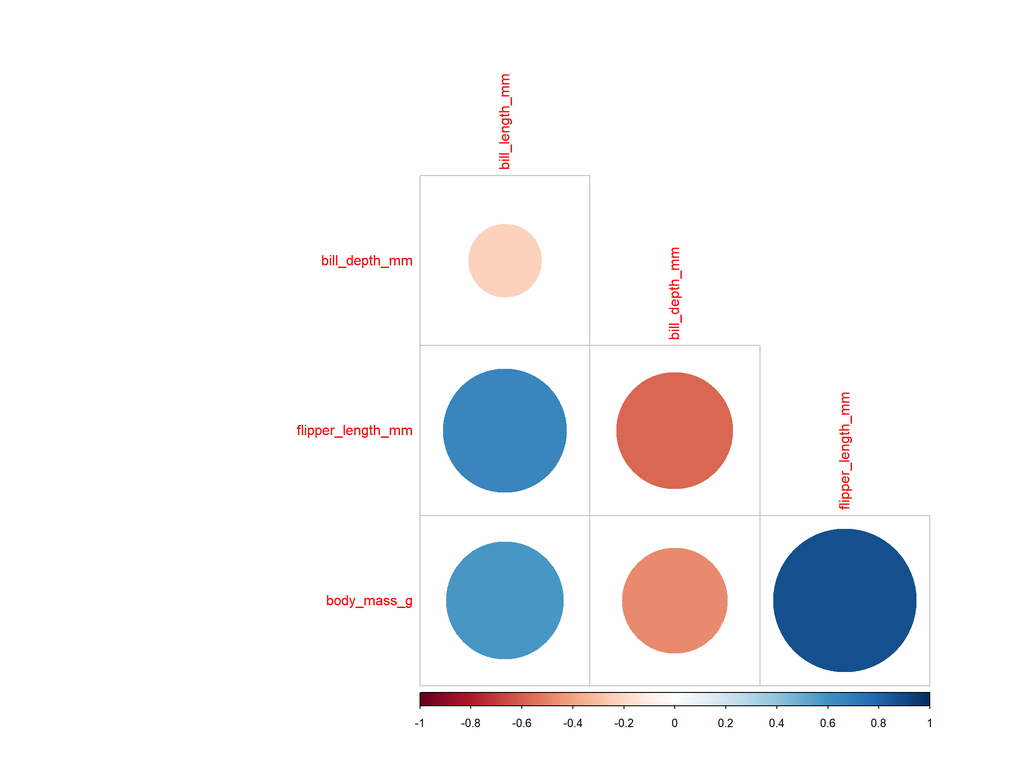

```r
penguins_numeric <- penguins_na_omit %>%
  select(-species, -sex, -island, -year)

# Cor-relation between numerics
corrplot(cor(penguins_numeric), type = 'lower', diag = FALSE)
```

Year is not a potential predictor for this problem so we have excluded it. There is a strong relationship between `body_mass_g` and `flipper_length_mm`. The pairs of measurement variables that have absolute correlations above 0.5 we list here:

```r
corr_matrtix <- cor(penguins_numeric)

corr_matrtix %>%
  as.data.frame %>%
  mutate(x = rownames(corr_matrtix)) %>%
  pivot_longer(
    cols = -x,
    names_to = 'y',
    values_to = 'corr') %>%
  filter(x < y) %>%
  filter(corr > 0.5 | corr < -0.5) %>%
  arrange(desc(abs(corr)))
```

```
## # A tibble: 4 x 3
##   x              y                   corr
##   <chr>          <chr>              <dbl>
## 1 body_mass_g    flipper_length_mm  0.873
## 2 bill_length_mm flipper_length_mm  0.653
## 3 bill_length_mm body_mass_g        0.589
## 4 bill_depth_mm  flipper_length_mm -0.578
```

We save the prepared data for use in Question #1.

```r
readr::write_rds(penguins_na_omit, 'data/penguins_na_omit.Rds')
```